# BMI 715 Final Project

Lance Lu, Harper Wang

2023-12-14

## Part 1: Research Question Statement

We are curious to see if we can spot any specific factors that tie in closely with the development of type 2 diabetes. This idea sparked from an article by the American Heart Association (https://www.heart.org/en/health-topics/diabetes/understand-your-risk-for-diabetes), which discusses various risk factors for diabetes.

We’re planning to sift through the `nhanes` data, pick out variables that are likely linked to diabetes (based on what the article suggests), and then dig into the data to see if these factors do have a connection with developing diabetes by trying to predict the probabilities of developing diabetes using the variables identified. Our main question is, “Could we build an effective predictive model for diabetes risk using the variables identified from `nhanes` using the guidance from the article?” Our focus will be on improving the accuracy of the predictive model and identifying which variable could give us the best insight.

## Part 2: Exploratory Data Analysis (EDA)

### Initial selection for dependent and independent variables

First, we load required libraries here.

```r
# Load necessary packages here
# install.packages("corrplot") install corrplot package if haven't
library(tidyverse)
library(ggplot2)
library(MASS)
library(corrplot)
```

### load raw dataset and clean the data

We downloaded the “nhanes_13_14_subset.csv” file from Canvas, load it, and clean the data pertaining to the variables that we are interested in. The following is an initial check of the number of missing values in the outcome and predictor variables.

Variable list  
- **MCQ300C:** Family history of diabetes in terms of the number of close relatives with diabetes: (1=Yes, 2=No, 9=Don’t know)  
- **RIDAGEYR:** Age when taking the survey (0-79=0-79 years’ old, 80=80 years’ old or more)  
- **RIDRETH3:** Race: 1=Mexican American, 2=Other Hispanic, 3=Non-Hispanic White, 4=Non-Hispanic Black, 6=Non-Hispanic Asian, 7=Other Race (multi-racial included)  
- **BPXML1:** Maximum inflation levels of blood pressure in mmHg (100-240=measured value, 888=could not obtain)  
- **BMXBMI:** Body Mass Index (kg/m^2)  
- **PAQ715:** Hours using computers or playing video games per day in past 30 days (0=less than 1 hour, 1-4=1-4 hours, 5=5 hours or more, 8=don’t use a computer outside school)  
- **PAQ710:** Hours watching TV or videos per day in past 30 days (0=less than 1 hour, 1-4=1-4 hours, 5=5 hours or more, 8=don’t watch TV or videos, 77=refused, 99=don’t know)  
- **LBXTC:** Total cholesterol (mg/dL)  
- **DIQ010:** Whether a doctor has diagnosed diabetes (1=Yes, 2=No, 3=Borderline, 7=Refused, 9=Don’t know)

```r
nhanes <- read.csv("nhanes_13_14_subset.csv")
"MCQ300C" %in% names(nhanes) # family history of diabetes
```

```
## [1] TRUE
```

```r
"RIDAGEYR" %in% names(nhanes) # age at survey
```

```
## [1] TRUE
```

```r
"RIDRETH3" %in% names(nhanes) # race information
```

```
## [1] TRUE
```

```r
"BPXML1" %in% names(nhanes) # blood pressure
```

```
## [1] TRUE
```

```r
"BMXBMI" %in% names(nhanes) # BMI
```

```
## [1] TRUE
```

```r
"PAQ715" %in% names(nhanes) # Hours use computer past 30 days
```

```
## [1] TRUE
```

```r
"PAQ710" %in% names(nhanes) # Hours watch TV or videos past 30 days
```

```
## [1] TRUE
```

```r
"LBXTC" %in% names(nhanes) # Total Cholesterol(mg/dL)
```

```
## [1] TRUE
```

```r
"DIQ010" %in% names(nhanes) # Doctor told you have diabetes
```

```
## [1] TRUE
```

```r
sapply(nhanes[c("MCQ300C", "RIDAGEYR", "RIDRETH3", "BPXML1", "BMXBMI", "PAQ715", "PAQ710", "LBXTC", "DIQ010")], function(x) sum(is.na(x)))
```

```
##  MCQ300C RIDAGEYR RIDRETH3   BPXML1   BMXBMI   PAQ715   PAQ710    LBXTC
##     4406        0        0     2622     1120      727      727     2551
##   DIQ010
##      406
```

### subsetting the dataframe

```r
df <- nhanes[c("MCQ300C", "RIDAGEYR", "RIDRETH3", "BPXML1", "BMXBMI", "PAQ715", "PAQ710", "LBXTC", "DIQ010")]
df <- na.omit(df)
names(df) <- c("family_history","age","race","blood_pressure","BMI","computer_hrs","tv_hrs","total_cholestrol","diabetes")
head(df)
```

```
##   family_history age race blood_pressure  BMI computer_hrs tv_hrs
## 1              1  69    4            140 26.7            8      2
## 2              1  54    3            170 28.6            8      4
## 3              2  72    3            160 28.9            0      4
## 5              2  73    3            170 19.7            1      1
## 6              2  56    1            180 41.7            8      5
## 8              2  61    3            150 35.7            0      0
##   total_cholestrol diabetes
## 1              167        1
## 2              170        1
## 3              126        1
## 5              201        2
## 6              226        2
## 8              168        2
```

### dealing with the observations with ambiguous responses, such as don’t know, could not obtain, and refused

```r
df_ini <- df %>%
  filter(family_history != 9, blood_pressure != 888, tv_hrs != 77, tv_hrs != 99, diabetes != 7, diabetes != 9)
head(df_ini)
```

```
##   family_history age race blood_pressure  BMI computer_hrs tv_hrs
## 1              1  69    4            140 26.7            8      2
## 2              1  54    3            170 28.6            8      4
## 3              2  72    3            160 28.9            0      4
## 4              2  73    3            170 19.7            1      1
## 5              2  56    1            180 41.7            8      5
## 6              2  61    3            150 35.7            0      0
##   total_cholestrol diabetes
## 1              167        1
## 2              170        1
## 3              126        1
## 4              201        2
## 5              226        2
## 6              168        2
```

### Adjusting values for each variable

```r
df_cle <- df_ini %>%
  mutate(
    family_history = factor(family_history, levels = c(1, 2),
                  labels = c("Yes", "No")),
  race = factor(race, levels = c(1, 2, 3, 4, 6, 7),
                  labels = c("Mexican American", "Other Hispanic", "White", "Black", "Asian", "Other")),
  diabetes = factor(diabetes, levels = c(1, 2, 3),
                  labels = c("Yes", "No", "Borderline")),
  computer_hrs = case_when(
    computer_hrs == 0 ~ 1,
    computer_hrs == 8 ~ 0,
    TRUE ~ computer_hrs
  ),
  tv_hrs = case_when(
    tv_hrs == 0 ~ 1,
    tv_hrs == 8 ~ 0,
    TRUE ~ tv_hrs
  )) %>%
  mutate(
    computer_hrs = factor(computer_hrs,
      levels = c(0, 1, 2, 3, 4, 5),
      labels = c("0", "<= 1", "2", "3", "4", ">= 5")
    ),
    tv_hrs = factor(tv_hrs,
      levels = c(0, 1, 2, 3, 4, 5),
      labels = c("0", "<= 1", "2", "3", "4", ">= 5")
    ))
head(df_cle)
```

```
##   family_history age             race blood_pressure  BMI computer_hrs tv_hrs
## 1            Yes  69            Black            140 26.7            0      2
## 2            Yes  54            White            170 28.6            0      4
## 3             No  72            White            160 28.9         <= 1      4
## 4             No  73            White            170 19.7         <= 1   <= 1
## 5             No  56 Mexican American            180 41.7            0   >= 5
## 6             No  61            White            150 35.7         <= 1   <= 1
##   total_cholestrol diabetes
## 1              167      Yes
## 2              170      Yes
## 3              126      Yes
## 4              201       No
## 5              226       No
## 6              168       No
```

### initial plot of relationships between variables

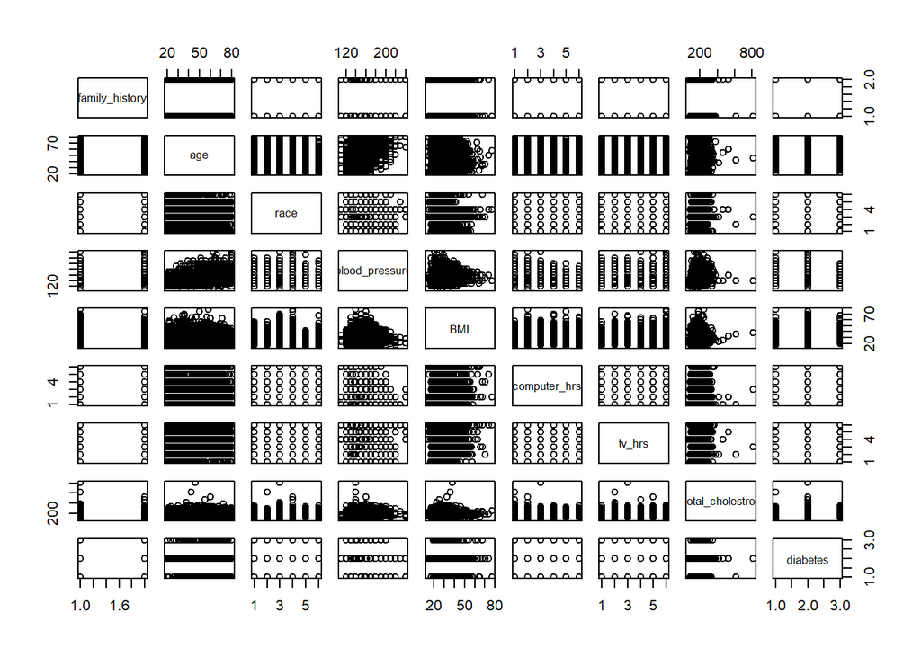

```r
plot(df_cle)
```

### plots exploring relationship between variables

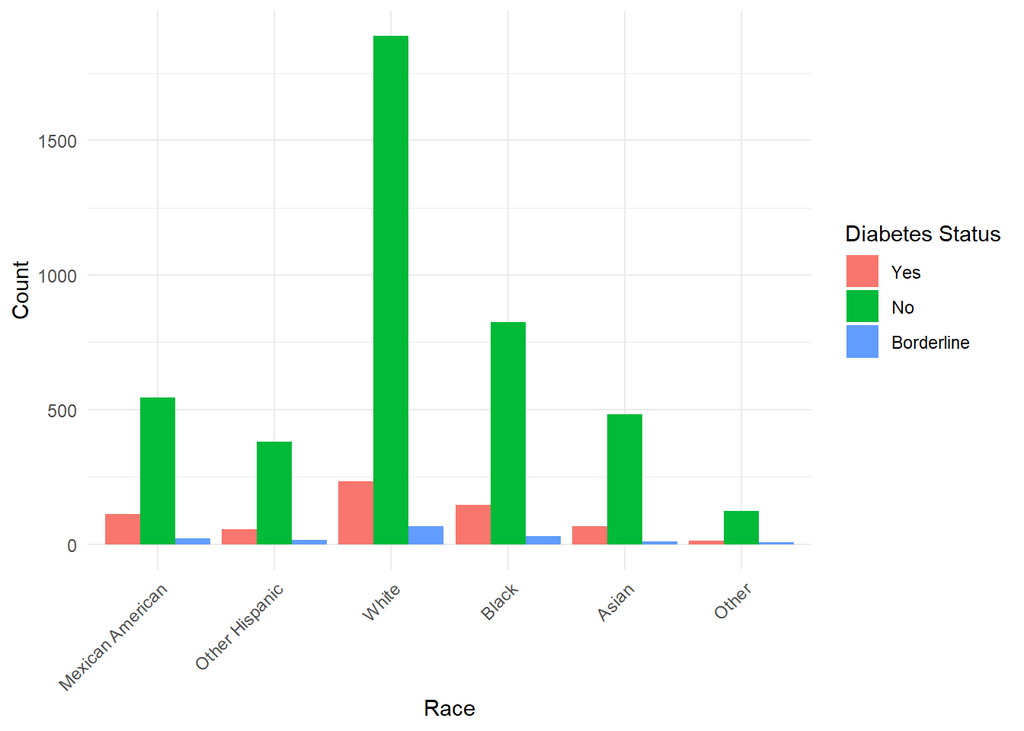

```r
race_diabetes <- ggplot(df_cle, aes(x = race, fill = diabetes)) +
  geom_bar(position = "dodge") +
  labs(x = "Race", y = "Count", fill = "Diabetes Status") +
  theme_minimal() +
  theme(axis.text.x = element_text(angle = 45, hjust = 1))
fam_diabetes <- ggplot(df_cle, aes(x = family_history, fill = diabetes)) +
  geom_bar(position = "dodge") +
  labs(x = "Whether close relative has diabetes", y = "Count", fill = "Diabetes Status") +
  theme_minimal() +
  theme(axis.text.x = element_text(angle = 45, hjust = 1))
comp_diabetes <- ggplot(df_cle, aes(x = computer_hrs, fill = diabetes)) +
  geom_bar(position = "dodge") +
  labs(x = "Time using computers or playing video games per day (hours)", y = "Count", fill = "Diabetes Status") +
  theme_minimal() +
  theme(axis.text.x = element_text(angle = 45, hjust = 1))
tv_diabetes <- ggplot(df_cle, aes(x = tv_hrs, fill = diabetes)) +
  geom_bar(position = "dodge") +
  labs(x = "Time watching TV or videos per day (hours)", y = "Count", fill = "Diabetes Status") +
  theme_minimal() +
  theme(axis.text.x = element_text(angle = 45, hjust = 1))
print(race_diabetes)
```

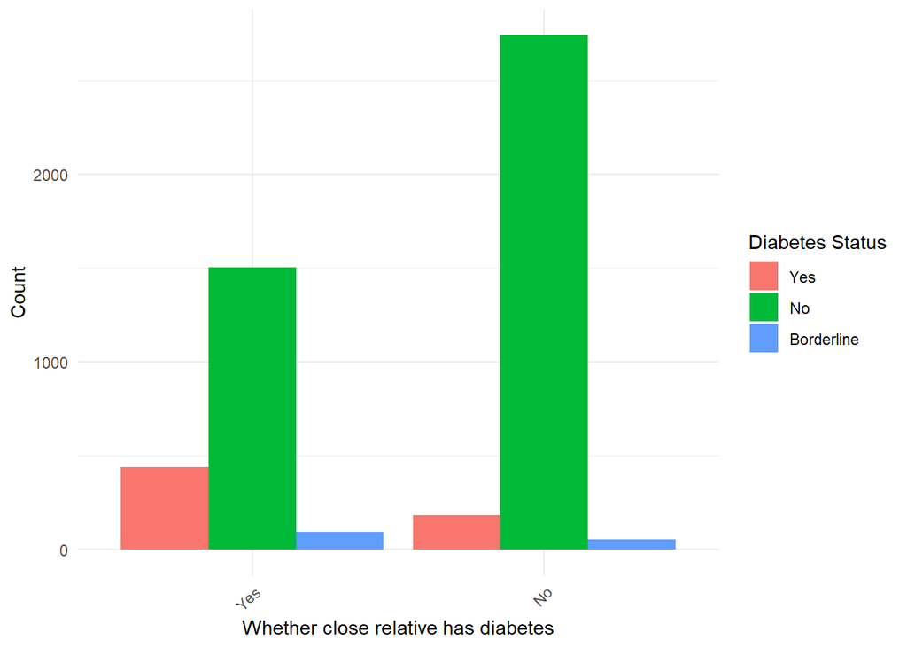

```r
print(fam_diabetes)
```

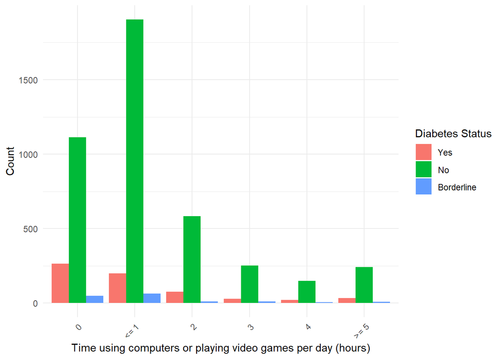

```r
print(comp_diabetes)
```

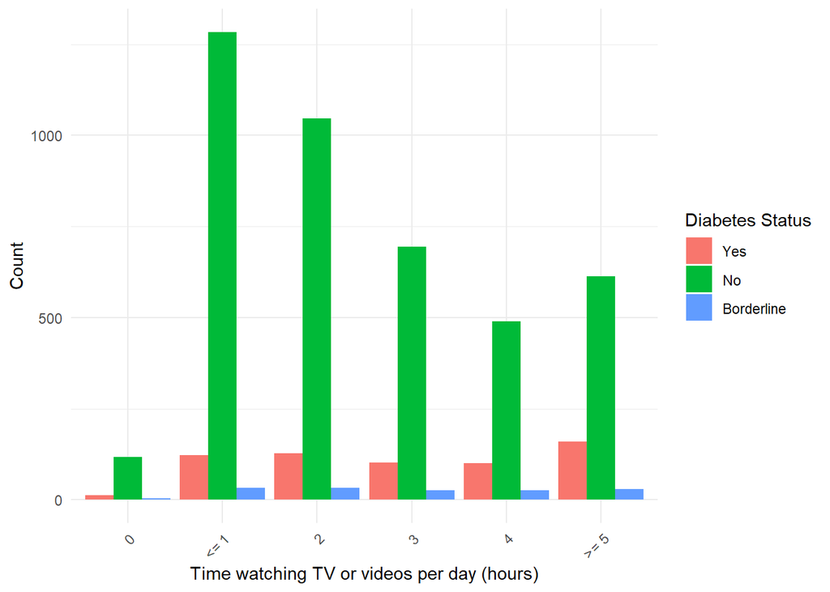

```r
print(tv_diabetes)
```

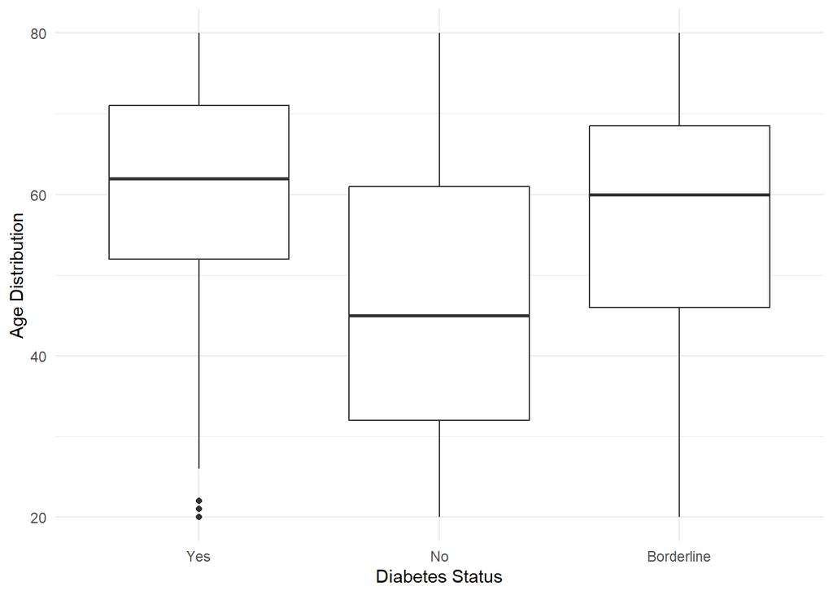

```r
age_diabetes <- ggplot(df_cle, aes(x = diabetes, y = age)) +
  geom_boxplot() +
  labs(x = "Diabetes Status", y = "Age Distribution") +
  theme_minimal()
bp_diabetes <- ggplot(df_cle, aes(x = diabetes, y = blood_pressure)) +
  geom_boxplot() +
  labs(x = "Diabetes Status", y = "Blood Pressure Distribution (mmHg)") +
  theme_minimal()
bmi_diabetes <- ggplot(df_cle, aes(x = diabetes, y = BMI)) +
  geom_boxplot() +
  labs(x = "Diabetes Status", y = "BMI") +
  theme_minimal()
cholestrol_diabetes <- ggplot(df_cle, aes(x = diabetes, y = total_cholestrol)) +
  geom_boxplot() +
  labs(x = "Diabetes Status", y = "Total cholestrol (mg/dL)") +
  theme_minimal()
print(age_diabetes)
```

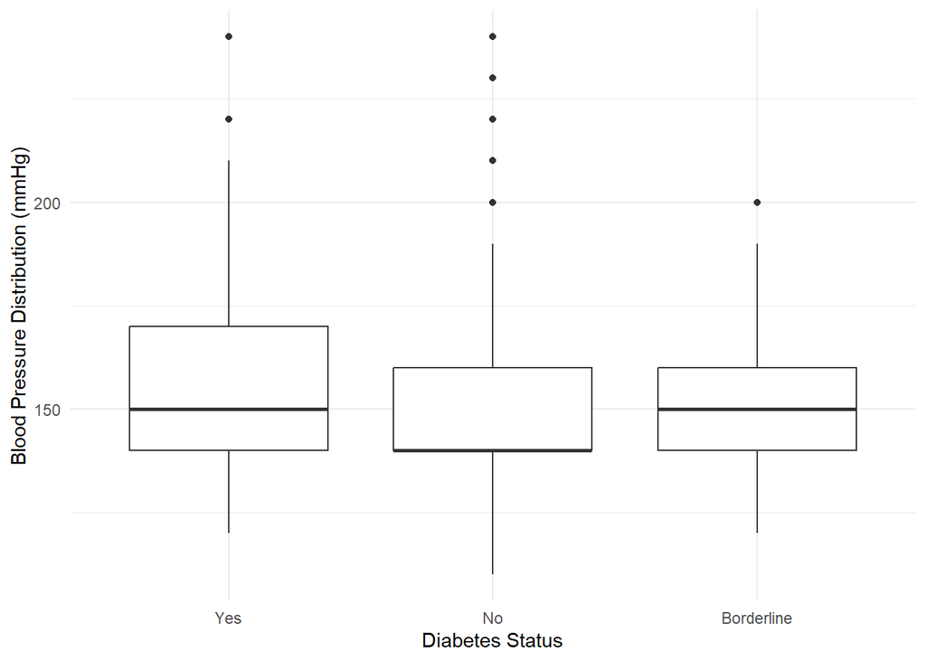

```r
print(bp_diabetes)
```

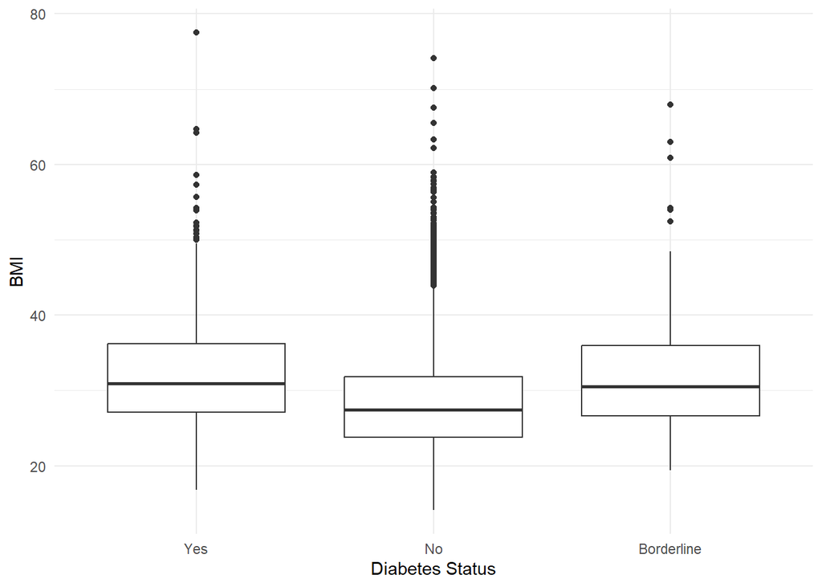

```r
print(bmi_diabetes)
```

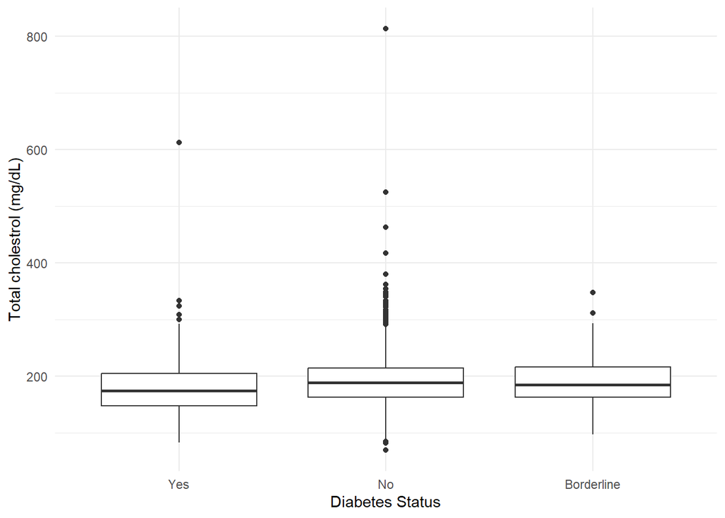

```r
print(cholestrol_diabetes)
```

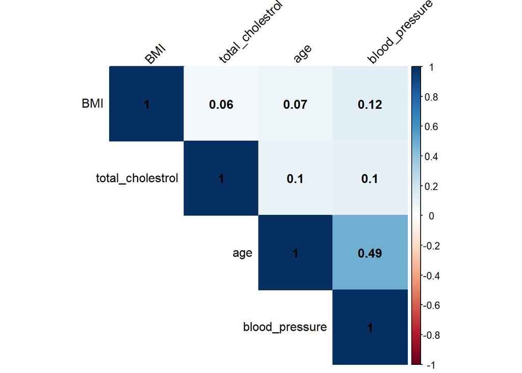

```r
cont <- c("age","blood_pressure","BMI","total_cholestrol")
cont_vars <- df_cle[, cont]
cor_matrix_cont <- cor(cont_vars, method = "spearman")
corrplot(cor_matrix_cont, method = "color", type = "upper", order = "hclust",
         tl.col = "black", tl.srt = 45, addCoef.col = "black")
```

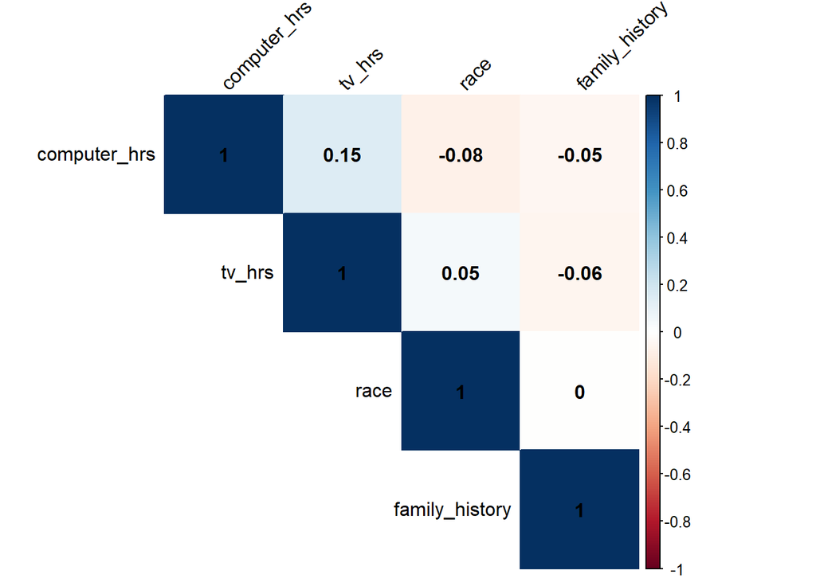

```r
cate <- c("race","family_history","computer_hrs","tv_hrs")
cate_vars <- df_ini[, cate]
cor_matrix_cate <- cor(cate_vars, method = "spearman")
corrplot(cor_matrix_cate, method = "color", type = "upper", order = "hclust",
         tl.col = "black", tl.srt = 45, addCoef.col = "black")
```

### perform scaling on continuous variables

```r
df_cle_scale <- df_cle %>%
  mutate(age_scale = scale(age),
         bp_scale = scale(blood_pressure),
         bmi_scale = scale(BMI),
         cholestrol_scale = scale(total_cholestrol)) %>%
  dplyr::select(age_scale, bp_scale, bmi_scale, cholestrol_scale, family_history, race, computer_hrs, tv_hrs, diabetes)
head(df_cle_scale)
```

```
##   age_scale    bp_scale   bmi_scale cholestrol_scale family_history
## 1 1.1491940 -0.48898152 -0.33881873       -0.5281776            Yes
## 2 0.2883529  1.26940481 -0.06924950       -0.4564139            Yes
## 3 1.3213622  0.68327603 -0.02668594       -1.5089481             No
## 4 1.3787516  1.26940481 -1.33196854        0.2851443             No
## 5 0.4031317  1.85553359  1.78935942        0.8831752             No
## 6 0.6900788  0.09714726  0.93808816       -0.5042564             No
##               race computer_hrs tv_hrs diabetes
## 1            Black            0      2      Yes
## 2            White            0      4      Yes
## 3            White         <= 1      4      Yes
## 4            White         <= 1   <= 1       No
## 5 Mexican American            0   >= 5       No
## 6            White         <= 1   <= 1       No
```

## Part 3: Hypothesis Test

### test for statistical significance of age (contibuous variable)

From the box plot of the age distribution in each diabetes group, the age distribution aren’t normal and the sample sizes between groups varies greatly from different groups. Therefore, I would use a non-parametric test that compares the different of medians among various diabetes groups. Specifically, I would use Kruskal-Wallis test because there are 3 independent groups to compare.

Null hypothesis: The median of age among test participants with diabetes, without diabetes, and borderline cases are all equal.

Alternative hypothesis: At least one group’s median in age is different from the other groups’ medians in age among test participants with diabetes, without diabetes, and borderline cases.

```r
kruskal.test(age ~ diabetes, data = df_cle)
```

```
##
##  Kruskal-Wallis rank sum test
##
## data:  age by diabetes
## Kruskal-Wallis chi-squared = 401.61, df = 2, p-value < 2.2e-16
```

### test for statistical significance of family history (categorical variable)

Examined the number of cases under each category of the categorical variables, we found that whether the participants have close relatives that had diabetes was the most balanced case among all categorical variables, so we decided to conduct a statistical significance test of family history on diabetes. Since both the predictor and the response variables are categorical variables, and each cell value in the expected table is larger than 50, a Chi-squared Test was used to conduct the hypothesis test.

Null hypothesis: Family history does not affect the proportion of participants in each diabetes status category.

Alternative hypothesis: Family history does affect the proportion of individuals in each diabetes status category, such that there are more (or fewer) participants with diabetes, no diabetes, or borderline within the groups defined by family history than would be expected by random chance.

```r
contingency <- table(df_cle$family_history, df_cle$diabetes)
chi <- chisq.test(contingency)
print(chi$expected)
```

```
##
##            Yes       No Borderline
##   Yes 253.6515 1725.968    61.3804
##   No  370.3485 2520.032    89.6196
```

```r
print(chi)
```

```
##
##  Pearson's Chi-squared test
##
## data:  contingency
## X-squared = 308.33, df = 2, p-value < 2.2e-16
```